# Fourier Transformation

Lian

2016年11月7日

## Fourier Transfermation

- [Reference Site](http://www.di.fc.ul.pt/~jpn/r/fourier/fourier.html)

### 1.Complex Wave

Here are two examples of sine waves:

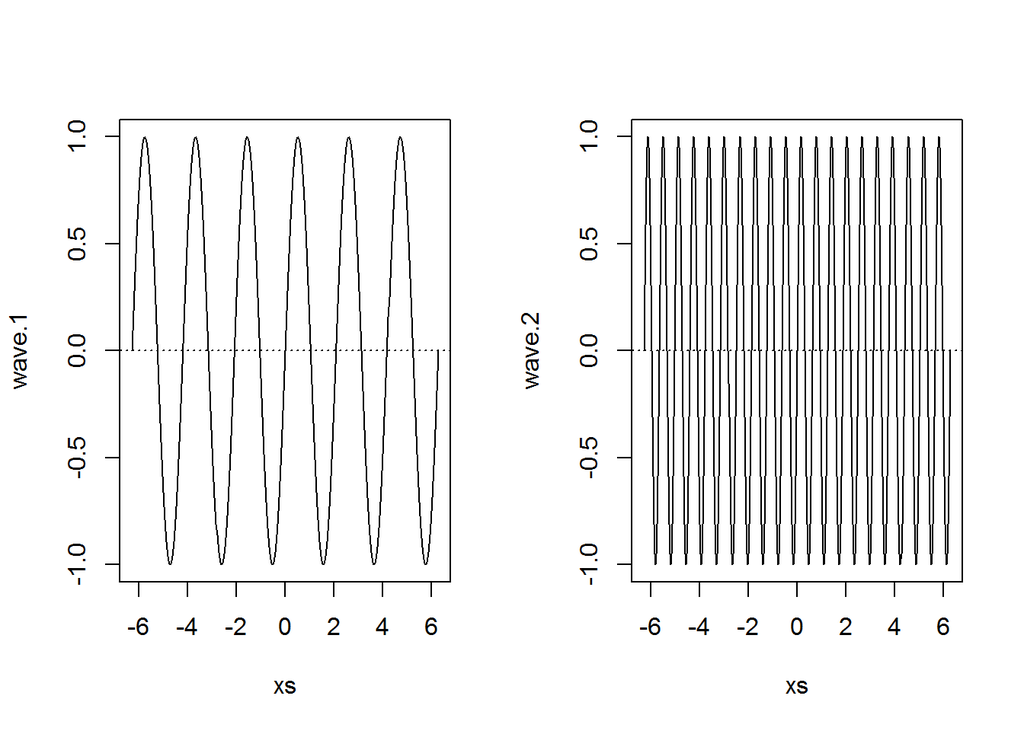

```r
xs <- seq(-2*pi,2*pi,pi/100)
wave.1 <- sin(3*xs)
wave.2 <- sin(10*xs)
par(mfrow = c(1, 2))
plot(xs, wave.1, type="l", ylim=c(-1,1)); abline(h=0,lty=3)
plot(xs, wave.2, type="l", ylim=c(-1,1)); abline(h=0,lty=3)
```

which can be linearly combined into a complex wave:

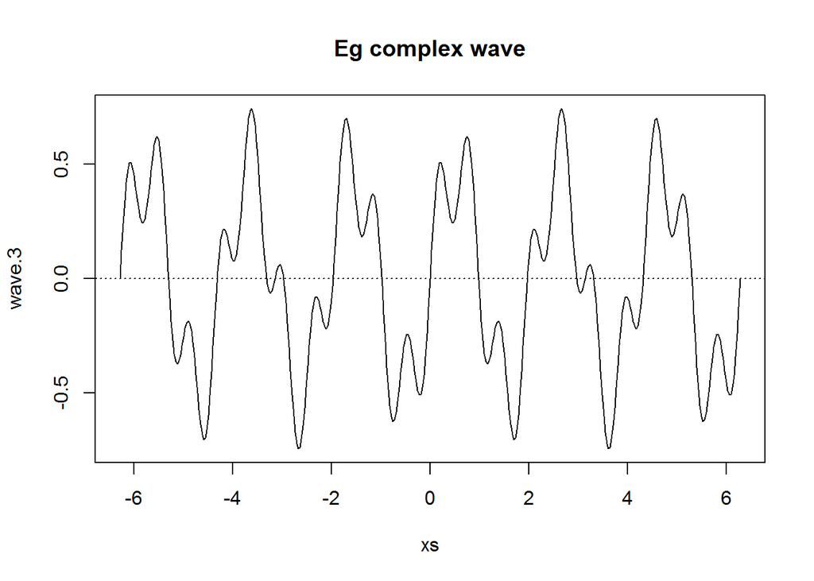

```r
par(mfrow = c(1, 1))
wave.3 <- 0.5 * wave.1 + 0.25 * wave.2
plot(xs,wave.3,type="l"); title("Eg complex wave"); abline(h=0,lty=3)
```

### 2.Fourier Series

Joseph Fourier showed that any periodic wave can be represented by a sum of simple sine waves. This sum is called the Fourier Series. The Fourier Series only holds while the system is linear. If there is, eg, some overflow effect (a threshold where the output remains the same no matter how much input is given), a non-linear effect enters the picture, breaking the sinusoidal wave and the superposition principle.

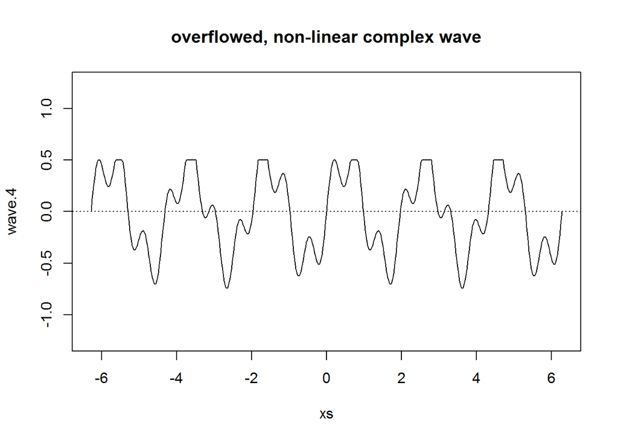

```r
par(mfrow = c(1, 1))
wave.4 <- wave.3
wave.4[wave.3>0.5] <- 0.5
plot(xs,wave.4,type="l",ylim=c(-1.25,1.25)); title("overflowed, non-linear complex wave"); abline(h=0,lty=3)
```

Also, the Fourier Series only holds if the waves are periodic, ie, they have a repeating pattern (non periodic waves are dealt by the Fourier Transform, see below).

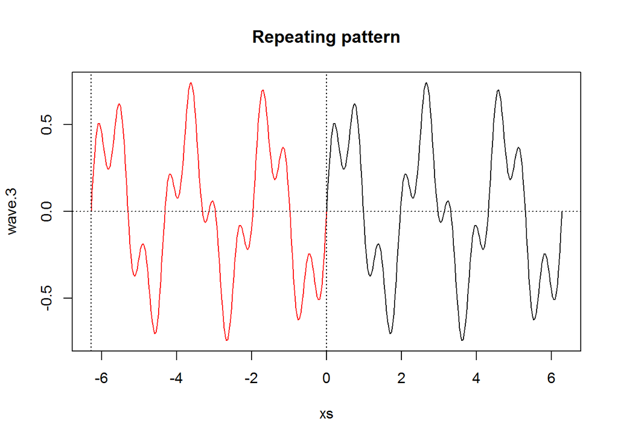

```r
repeat.xs <- seq(-2*pi,0,pi/100)
wave.3.repeat <- 0.5*sin(3*repeat.xs) + 0.25*sin(10*repeat.xs)
plot(xs,wave.3,type="l"); title("Repeating pattern")
points(repeat.xs,wave.3.repeat,type="l",col="red"); abline(h=0,v=c(-2*pi,0),lty=3)
```

Here’s a R function for plotting trajectories given a fourier series:

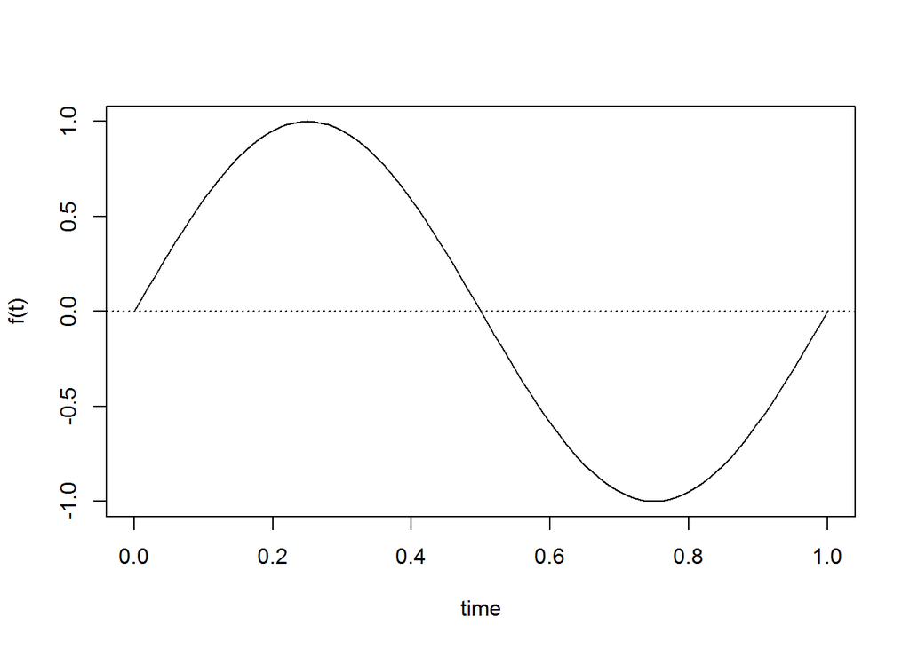

```r
plot.fourier <- function(fourier.series, f.0, ts) {
  w <- 2*pi*f.0
  trajectory <- sapply(ts, function(t) fourier.series(t,w))
  plot(ts, trajectory, type="l", xlab="time", ylab="f(t)"); abline(h=0,lty=3)
}

# An eg
plot.fourier(function(t,w) {sin(w*t)}, 1, ts=seq(0,1,1/100))
```

And the plotting of equation: $f(t)=0.5\times sin(3wt)+0.25\times sin(10wt)$

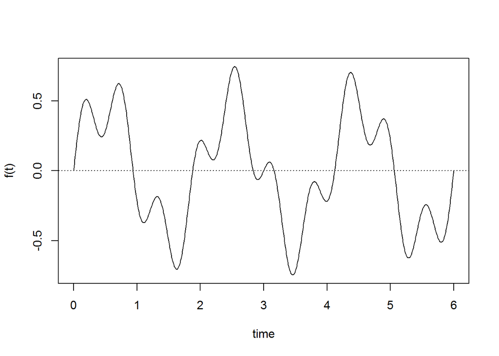

```r
acq.freq <- 100                    # data acquisition frequency (Hz)
time     <- 6                      # measuring time interval (seconds)
ts       <- seq(0,time,1/acq.freq) # vector of sampling time-points (s)
f.0      <- 1/time                 # fundamental frequency (Hz)

dc.component       <- 0
component.freqs    <- c(3,10)      # frequency of signal components (Hz)
component.delay    <- c(0,0)       # delay of signal components (radians)
component.strength <- c(.5,.25)    # strength of signal components

f <- function(t,w) {
  dc.component +
  sum( component.strength * sin(component.freqs*w*t + component.delay))
}

plot.fourier(f,f.0,ts)
```

### 3.Phase Shifts

Another feature of the fourier series is phase shift. Phase shifts are translations in the x-axis for a given wave component. These shifts are measured in angles (radians).
$$f(t)=0.5\times sin(3wt+\frac{\pi}{2})+0.25\times sin(10wt)$$

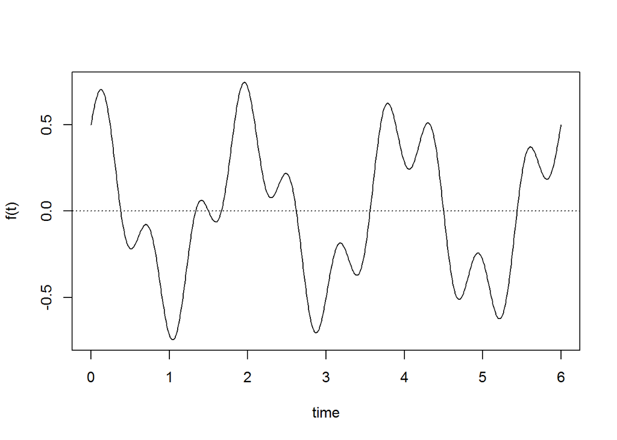

```r
component.delay <- c(pi/2,0)       # delay of signal components (radians)
plot.fourier(f,f.0,ts)
```

### 4.DC Components

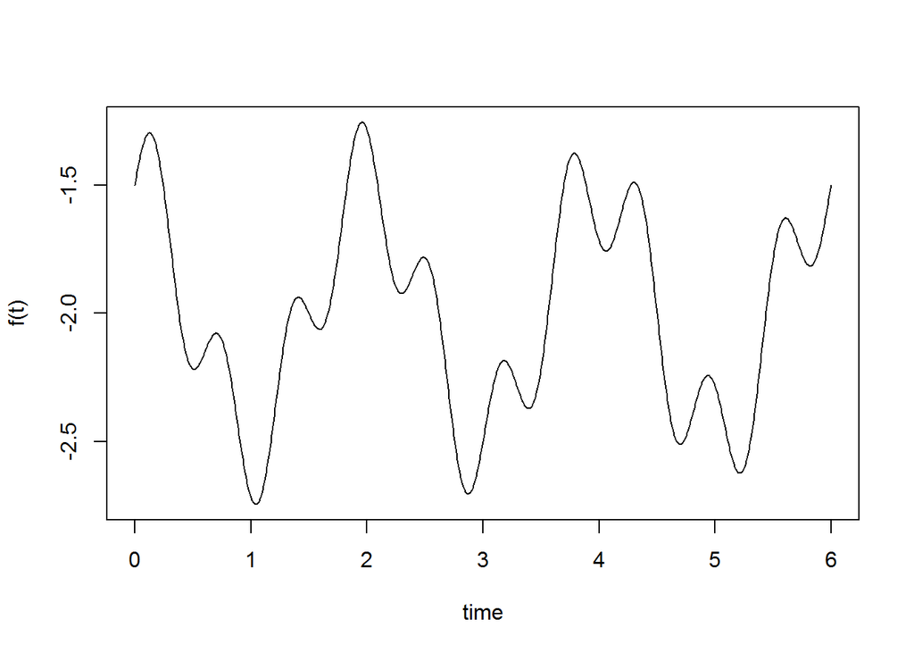

```r
dc.component <- -2
plot.fourier(f,f.0,ts)
```

### 5.Fourier Transform

The Fourier Transform (FT) is a generalization to solve for non-periodic waves. The FT assumes that the finite analyzed segment corresponds to one period of an infinitely extended periodic signal.

**Given a trajectory the fourier transform (FT) breaks it into a set of related cycles that describes it. Each cycle has a strength, a delay and a speed.**

So, the FT algorithm receives a trajectory, apply its filters to find the appropriate cycles, and outputs the full set of cyclic components. There are two algorithms:

- the Discrete Fourier Transform (DFT) which requires $O(n^2)$ operations (for n samples)
- the Fast Fourier Transform (FFT) which requires $O(n.log(n))$ operations

This tutorial does not focus on the algorithms. There’s a R function called `fft` that computes the FFT.